# regular

```
library(xts)
library(tseries)
library(forecast)
library(ggfortify)
library(lmtest)
library(fUnitRoots)
```

## R Markdown

importaciones

```
regularC <- read.csv("seriec.csv")
regularI <- read.csv("seriei.csv")
```

inciso 2b

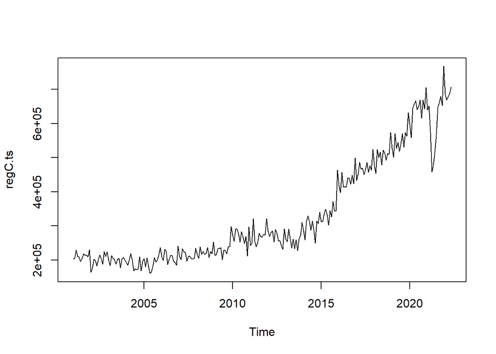

```r
plot(regC.ts)
```

inciso 2a para consumo gasolina regular

```r
start(regC.ts)#inicio
```

```
## [1] 2001    1
```

```r
end(regC.ts)#fin
```

```
## [1] 2022    5
```

```r
frequency(regC.ts) #frequencia
```

```
## [1] 12
```

Determine si es necesario transformar la serie: se cree que si es necesario dado la no estacionariedad de la data.

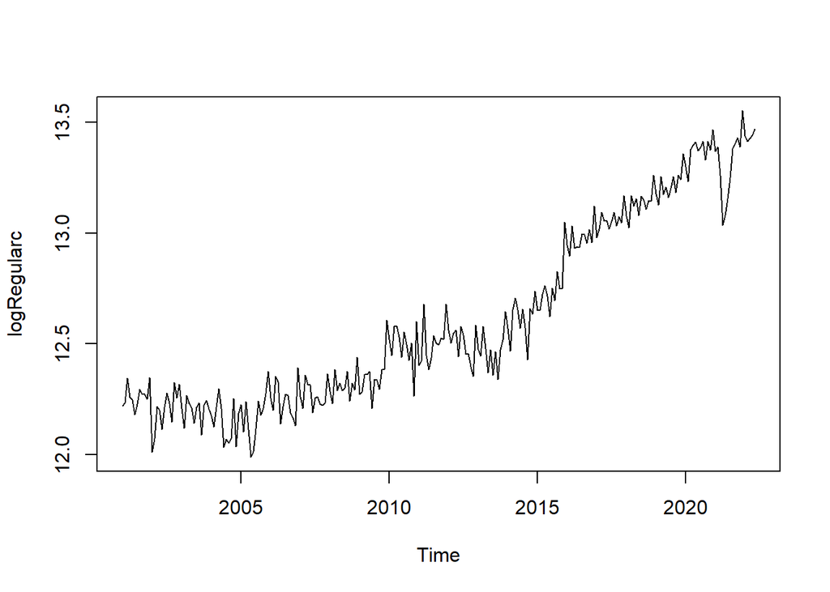

```r
logRegularc<- log(regC.ts)
plot(logRegularc)
```

como se puede apreciar no es estacionaria:

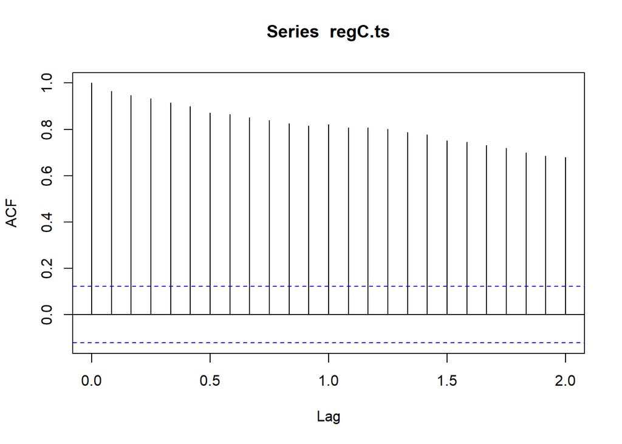

```r
acf(regC.ts)
```

Test de Dickey-fuller para probar si es estacionaria

```r
adf.test(regC.ts) #test ADF
```

```
##
##  Augmented Dickey-Fuller Test
##
## data:  regC.ts
## Dickey-Fuller = -1.396, Lag order = 6, p-value = 0.8302
## alternative hypothesis: stationary
```

Se usa la funcion auto.arima() para que nos devuelva los parametros del modelo arima.

```r
auto.arima(regC.ts)#obtecion del modelo
```

```
## Series: regC.ts
## ARIMA(2,1,1)(2,0,0)[12] with drift
##
## Coefficients:
##          ar1     ar2      ma1    sar1    sar2     drift
##       0.5885  0.1500  -0.9404  0.2678  0.4421  1852.202
## s.e.  0.0749  0.0676   0.0331  0.0622  0.0648  1051.319
##
## sigma^2 estimated as 598633474:  log likelihood=-2951.32
## AIC=5916.64   AICc=5917.09   BIC=5941.45
```

Creacion de modelos arima inciso 2f y 2g:

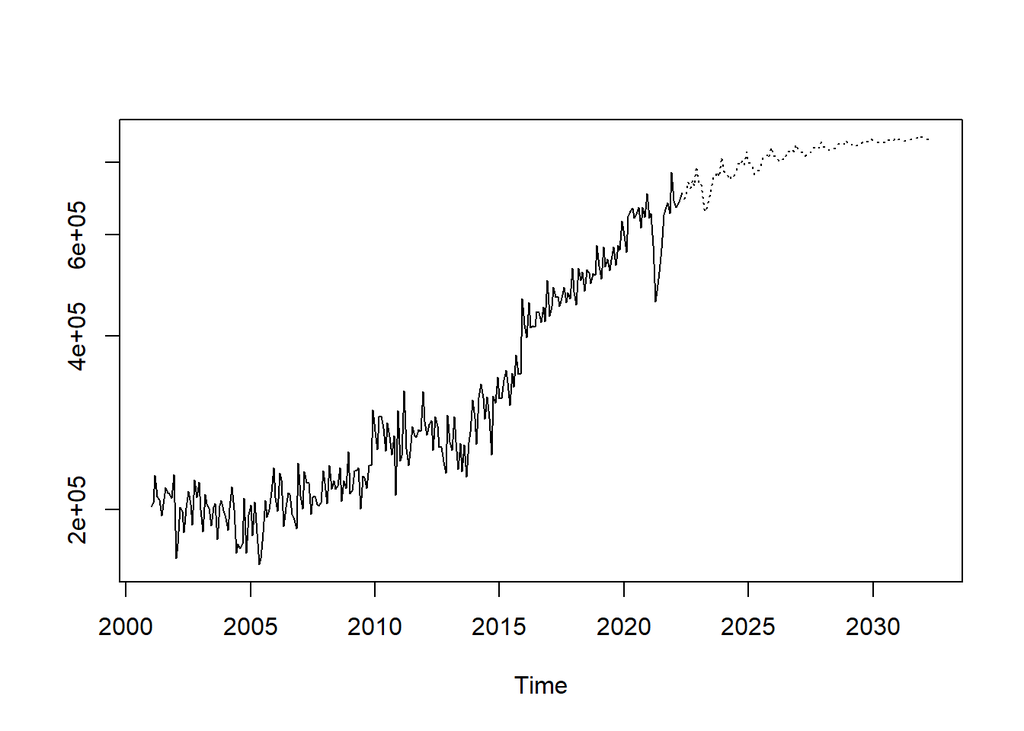

```r
fit <- arima(log(regC.ts), c(2, 1, 1),seasonal = list(order = c(2, 0, 0), period = 12)) #modleo arima con valores dados por la funcion auto.arima()
pred <- predict(fit, n.ahead = 10*12)
ts.plot(regC.ts,2.718^pred$pred, log = "y", lty = c(1,3))
```

```r
fit2 <- arima(log(regC.ts), c(2, 1, 1),seasonal = list(order = c(0, 1, 0), period = 12))

forecastAP <- forecast(fit, level = c(95), h = 36)
forecastAD <- forecast(fit2, level = c(95), h = 5)
```

Analisis residuales:

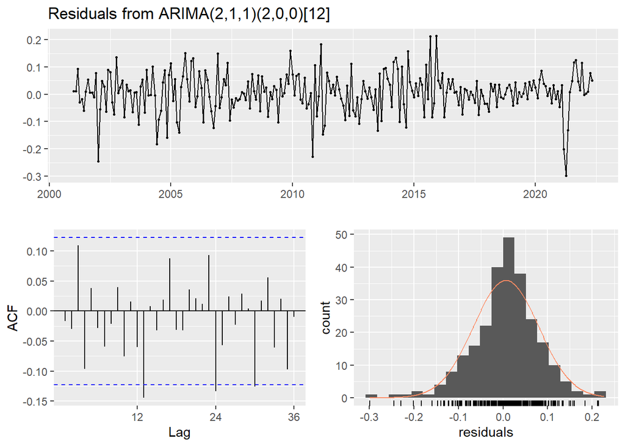

```
##
##  Ljung-Box test
##
## data:  Residuals from ARIMA(2,1,1)(2,0,0)[12]
## Q* = 27.401, df = 19, p-value = 0.09565
##
## Model df: 5.   Total lags used: 24
```

```r
checkresiduals(fit)
```

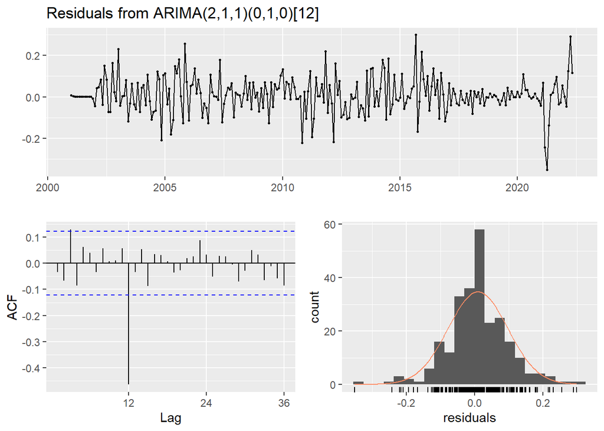

```
##
##  Ljung-Box test
##
## data:  Residuals from ARIMA(2,1,1)(0,1,0)[12]
## Q* = 76.838, df = 21, p-value = 2.707e-08
##
## Model df: 3.   Total lags used: 24
```

```r
checkresiduals(fit2)
```

```r
coeftest(fit)
```

```
##
## z test of coefficients:
##
##       Estimate Std. Error z value  Pr(>|z|)
## ar1   0.280690   0.196674  1.4272    0.1535
## ar2   0.062128   0.127896  0.4858    0.6271
## ma1  -0.767032   0.180614 -4.2468 2.169e-05 ***
## sar1  0.285308   0.060885  4.6860 2.785e-06 ***
## sar2  0.351166   0.062312  5.6356 1.745e-08 ***
## ---
## Signif. codes:  0 '***' 0.001 '**' 0.01 '*' 0.05 '.' 0.1 ' ' 1
```

```r
coeftest(fit2)
```

```
##
## z test of coefficients:
##
##      Estimate Std. Error z value  Pr(>|z|)
## ar1  0.532290   0.064866   8.206 2.286e-16 ***
## ar2  0.180569   0.065732   2.747  0.006014 **
## ma1 -0.979630   0.014844 -65.993 < 2.2e-16 ***
## ---
## Signif. codes:  0 '***' 0.001 '**' 0.01 '*' 0.05 '.' 0.1 ' ' 1
```

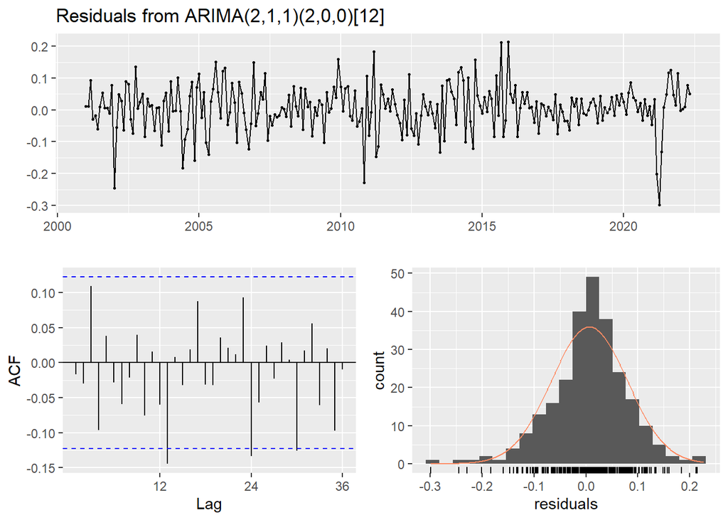

```
##
##  Ljung-Box test
##
## data:  Residuals from ARIMA(2,1,1)(2,0,0)[12]
## Q* = 27.401, df = 19, p-value = 0.09565
##
## Model df: 5.   Total lags used: 24
```

```r
checkresiduals(fit)
```

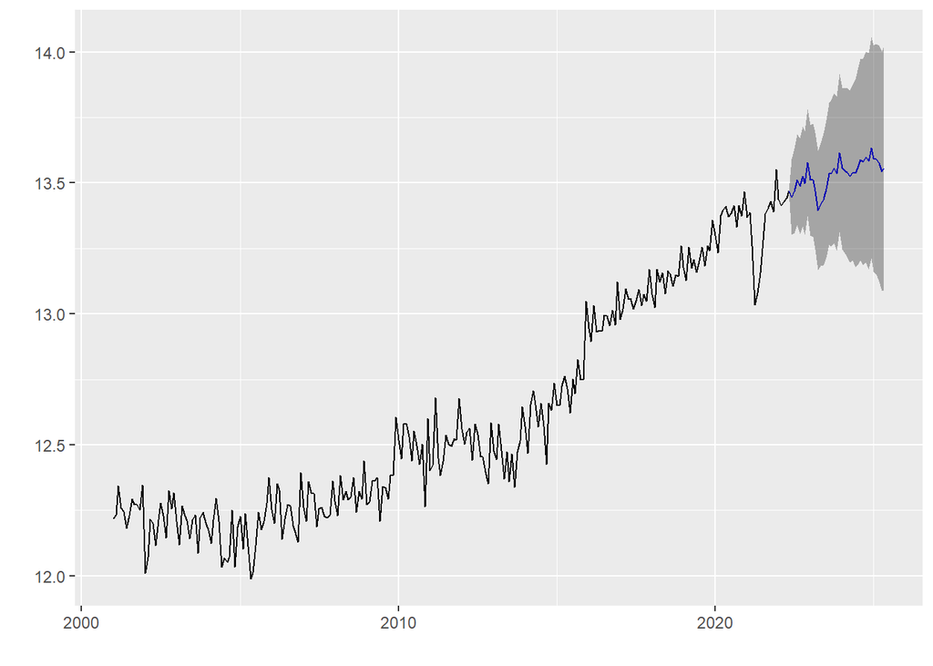

```r
autoplot(forecastAP)
```

Se puede apreciar que solo el primero modelo es viable para realizar predicciones dado su nivel de significancia de 0.09.

#importacion

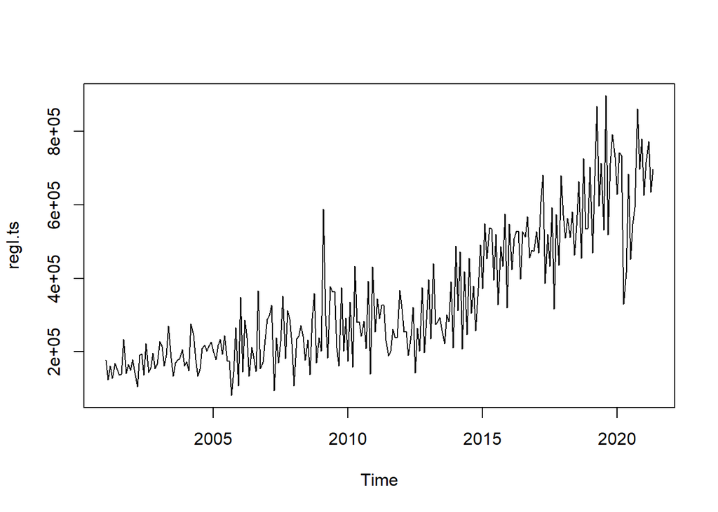

```r
regI.ts<-ts(regularI$GasolinaRegular,start = c(2001,1),frequency = 12)
#grafico
plot(regI.ts)#La grafica demuestra que no hay estacionariedad
```

```r
#inicio
start(regI.ts)
```

```
## [1] 2001    1
```

```r
#fin
end(regC.ts)
```

```
## [1] 2022    5
```

```r
#frecuencia
frequency(regI.ts)
```

```
## [1] 12
```

transformacion logaritmica

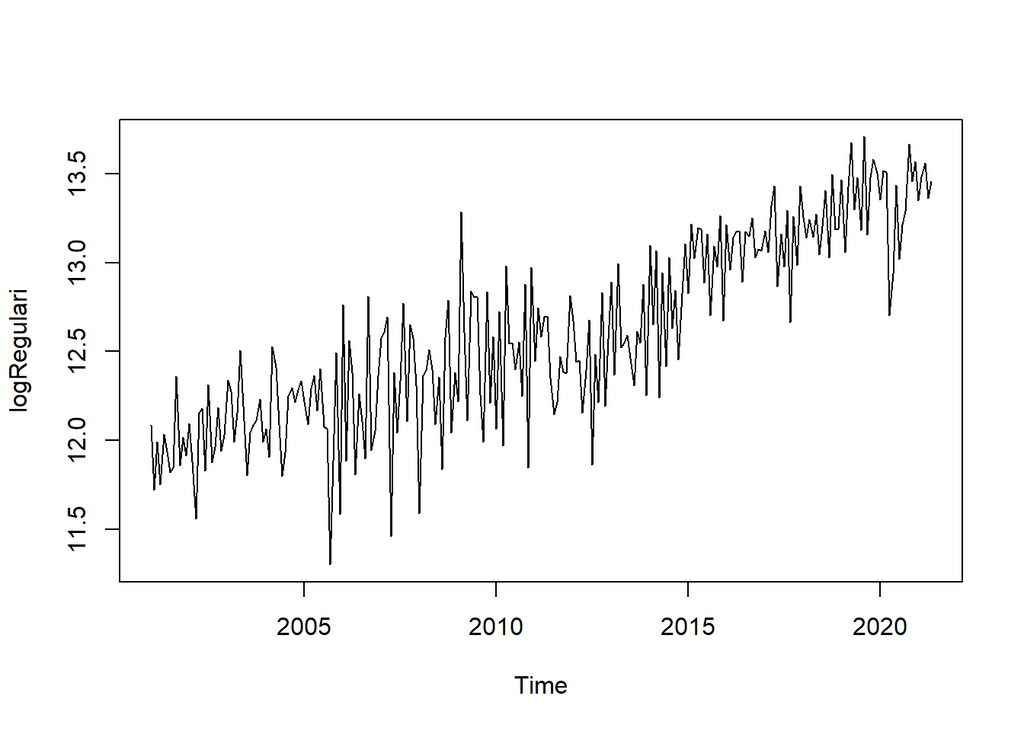

```r
logRegulari<- log(regI.ts)
plot(logRegulari)
```

autorrelacion:

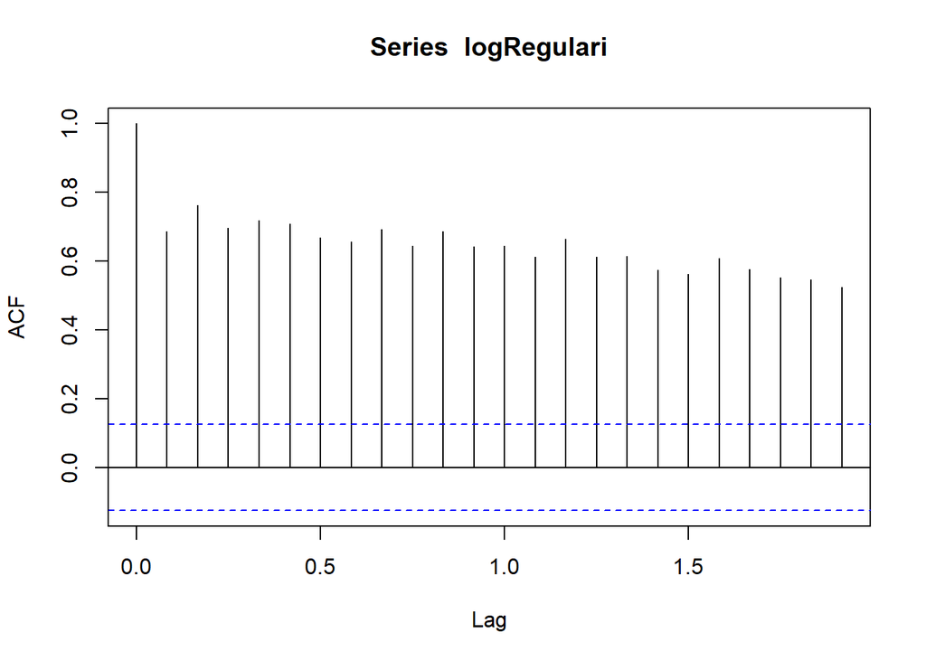

```r
acf(logRegulari) #autocorrelacion
```

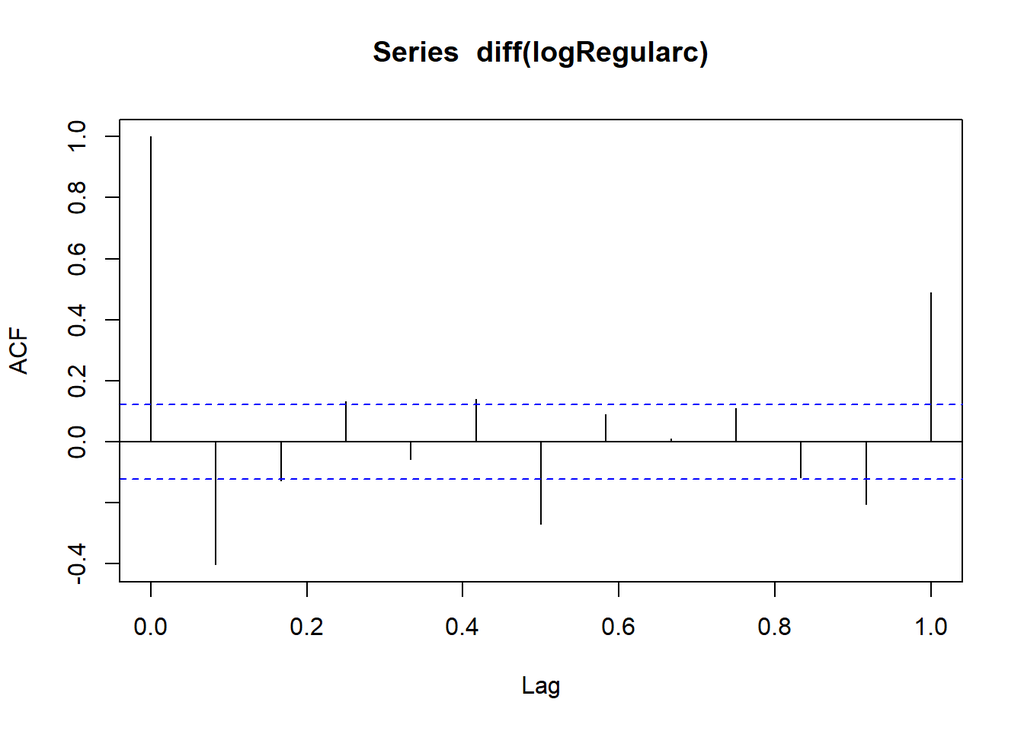

```r
acf(diff(logRegularc),12)#autocorrelacion corregida
```

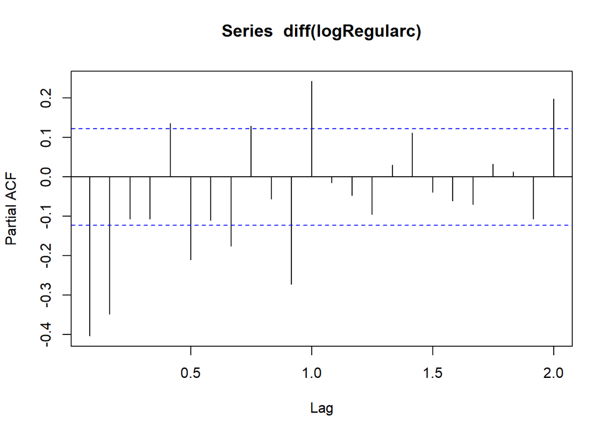

```r
pacf(diff(logRegularc))
```

este a la vez tampoco es estacionario.

Test de Dickey-fuller:

```r
adf.test(regI.ts) #test ADF
```

```
##
##  Augmented Dickey-Fuller Test
##
## data:  regI.ts
## Dickey-Fuller = -3.1858, Lag order = 6, p-value = 0.09084
## alternative hypothesis: stationary
```

obteniendo parametros del modelo arima con la función auto:

```r
auto.arima(regI.ts)#obtecion del modelo
```

```
## Series: regI.ts
## ARIMA(1,1,2) with drift
##
## Coefficients:
##           ar1      ma1      ma2     drift
##       -0.6647  -0.4049  -0.4089  2231.665
## s.e.   0.1652   0.1920   0.1792   642.947
##
## sigma^2 estimated as 7.728e+09:  log likelihood=-3122.79
## AIC=6255.58   AICc=6255.84   BIC=6273.07
```

creacion de modelos arima para serie de importacion

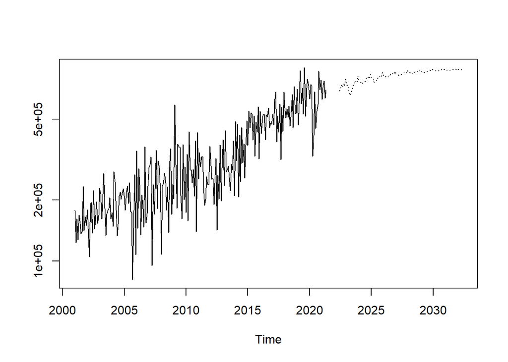

```r
fiti <- arima(log(regI.ts), c(1, 1, 2),seasonal = list(order = c(2, 0, 0), period = 12)) #modleo arima con valores dados por la funcion auto.arima()
pred <- predict(fit, n.ahead = 10*12)
ts.plot(regI.ts,2.718^pred$pred, log = "y", lty = c(1,3))
```

```r
fit2i <- arima(log(regI.ts),seasonal = list(order = c(0, 1, 0), period = 12))
```

analisis de residuales para la serie de importacion

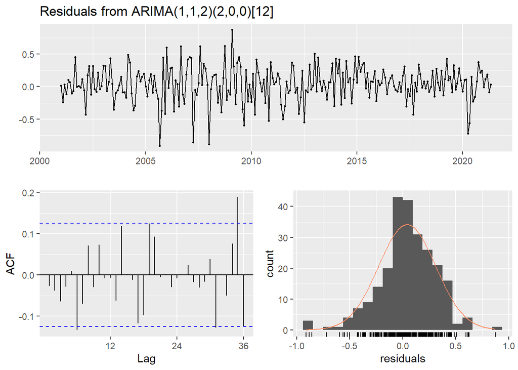

```
##
##  Ljung-Box test
##
## data:  Residuals from ARIMA(1,1,2)(2,0,0)[12]
## Q* = 28.207, df = 19, p-value = 0.07953
##
## Model df: 5.   Total lags used: 24
```

```r
checkresiduals(fiti)
```

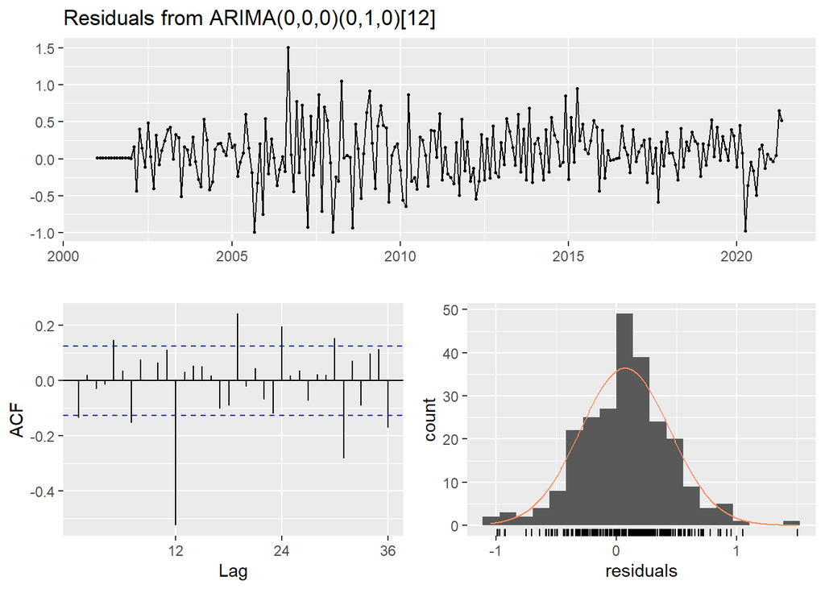

```
##
##  Ljung-Box test
##
## data:  Residuals from ARIMA(0,0,0)(0,1,0)[12]
## Q* = 132.62, df = 24, p-value < 2.2e-16
##
## Model df: 0.   Total lags used: 24
```

```r
checkresiduals(fit2i)
```

```r
coeftest(fiti)
```

```
##
## z test of coefficients:
##
##        Estimate Std. Error z value Pr(>|z|)
## ar1  -0.5419036  0.2036648 -2.6608 0.007796 **
## ma1  -0.5298048  0.2255976 -2.3485 0.018852 *
## ma2  -0.2808536  0.2024366 -1.3874 0.165330
## sar1  0.0051583  0.0648183  0.0796 0.936571
## sar2  0.1529973  0.0650106  2.3534 0.018602 *
## ---
## Signif. codes:  0 '***' 0.001 '**' 0.01 '*' 0.05 '.' 0.1 ' ' 1
```

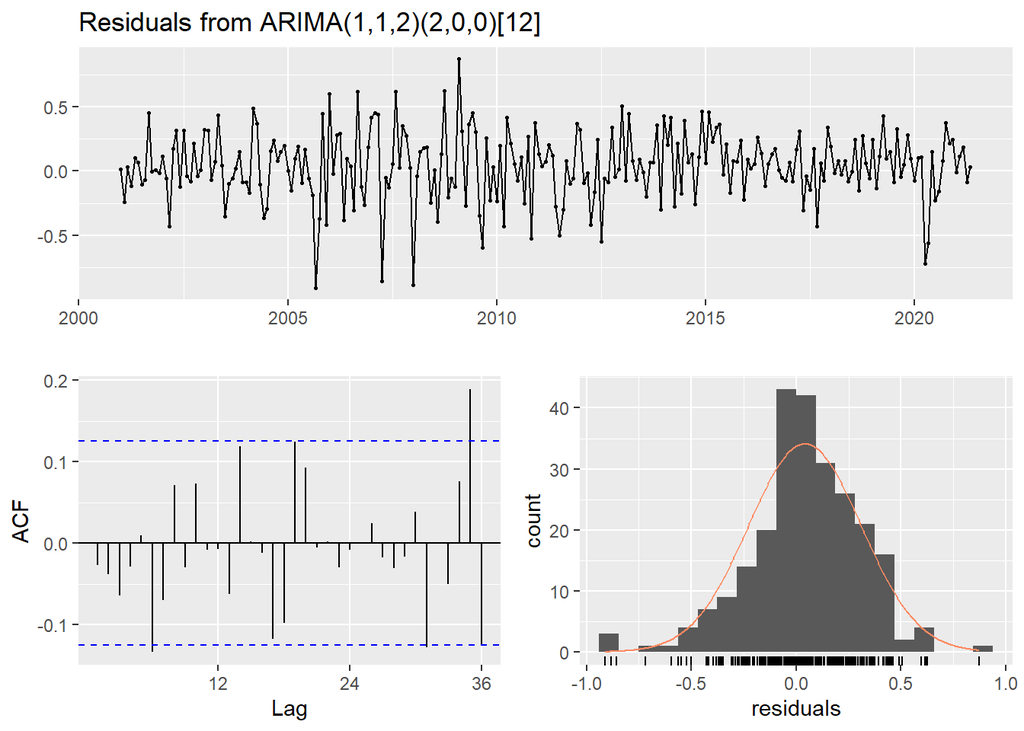

```
##
##  Ljung-Box test
##
## data:  Residuals from ARIMA(1,1,2)(2,0,0)[12]
## Q* = 28.207, df = 19, p-value = 0.07953
##
## Model df: 5.   Total lags used: 24
```

```r
checkresiduals(fiti)
```

Nuevamente solo el modelo que se implementó con los modelos del auto arima devolvió un nivel de significancia mayor a 0.05 por loi que es el unico viable para predicción.

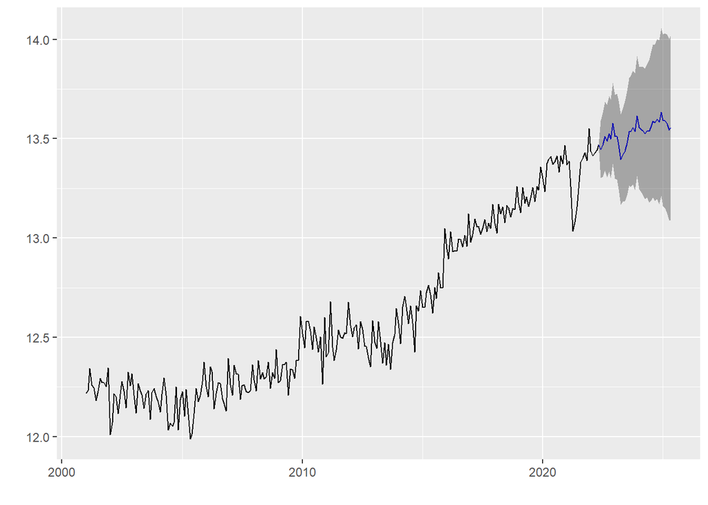

```r
forecastAPi2 <- forecast(fit, level = c(95), h = 36)
forecastAD <- forecast(fit2, level = c(95), h = 36)# a 3 años
autoplot(forecastAPi2)
```

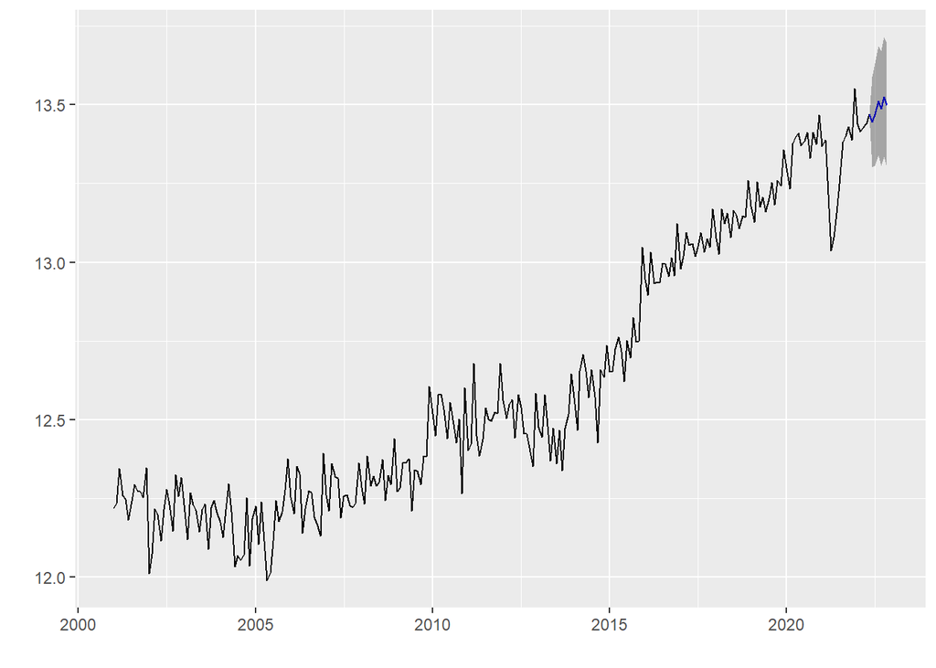

```r
forecastAPi <- forecast(fit, level = c(95), h = 6)# a 6 meses
forecastADi <- forecast(fit2, level = c(95), h = 6)


autoplot(forecastAPi)
```